# Differential Gene Expression of 37C vs 25C in YPD samples

Edward Wallace

2022-09-05

# Summary

Differential Gene Expression of 37C vs 25C in YPD samples at 1hr, using DESeq2

This analysis produces files:

- `deseq_df_37Cvs25C_YPD1hr.txt`
- `deglist_37Cvs25C_YPD1hr_up2x_FDR5.txt`
- `deglist_37Cvs25C_YPD1hr_down2x_FDR5.txt`

## Load count data from shared script load_count_data.Rmd

# Load and organise count data

`load_count_data.Rmd` is just to load and organise the raw count data in R, as well as loading libraries for data analysis. Other scripts can just run this one instead of duplicating code, especially scripts for differential gene expression analysis.

Note: the current version of this runs *after* `QC_PCA.Rmd`, which does the organisation. This just loads the organised counts from the file `results/summaries/counts_bysamplecode.txt`.

## Load the organised counts

```r
counts_all <-
  here::here("results", "summaries", "counts_bysamplecode.txt") %>%
  readr::read_tsv(comment = "#",
                  col_types = "ciiiiiiiiiiiiiiiiiiiiiiiiiiiiiiiiiiiii")   %>%
  magrittr::set_rownames(.$Gene)
counts_all
```

```
## # A tibble: 8,194 × 38
##    Gene       Length  YM9A  YC0A  YC1A  YC2A  YC3A  YC4A  YH1A  YH2A  YH3A  YH4A
##  * <chr>       <int> <int> <int> <int> <int> <int> <int> <int> <int> <int> <int>
##  1 CNAG_00002    773    16     1     0    31    13    12    12     3    35   130
##  2 CNAG_00003   1752    11    36    21    45    80   104    17    11    53   107
##  3 CNAG_00004   2547   131    65    94   120   367   349   182    45   233   453
##  4 CNAG_00005   2106    18     6     0    10    79   158    39    72   334   351
##  5 CNAG_00006   1091   201    77   190   198   301   285   371   169   271   628
##  6 CNAG_00007   1969   107    85    73   186   319   391   337   121   351   675
##  7 CNAG_00008   3648   190   132   126   370   403   729   517   280   741  1095
##  8 CNAG_00009   1473    42    14    13    71   219   428    51   119   195   375
##  9 CNAG_00010   3449   239    47   520  1204  2017  1562  1401   571   965  1744
## 10 CNAG_00011   1241    11    40    10    31    48    86    61    33    63   186
## # ℹ 8,184 more rows
## # ℹ 26 more variables: RC1A <int>, RC2A <int>, RC3A <int>, RC4A <int>,
## #   RH1A <int>, RH2A <int>, RH3A <int>, RH4A <int>, YM9B <int>, YC0B <int>,
## #   YC1B <int>, YC2B <int>, YC3B <int>, YC4B <int>, YH1B <int>, YH2B <int>,
## #   YH3B <int>, YH4B <int>, RC1B <int>, RC2B <int>, RC3B <int>, RC4B <int>,
## #   RH1B <int>, RH2B <int>, RH3B <int>, RH4B <int>
```

## Load the sample sheet

```r
sample_sheet <-
  here::here("input", "experiment",
             "CryptoWakeUpSampleSheetPlusTagsAndRawFilenames.txt") %>%
  readr::read_tsv(comment = "#") %>%
  dplyr::transmute(SampleID = as_factor(SampleID),
                   Code = as_factor(Code),
                   Medium = as_factor(Medium),
                   Temp = factor(Temp, levels = c("25C", "30C", "37C")),
                   Time = as.integer(Time),
                   Rep = as_factor(Rep),
                   MediumTemp = paste(Medium,Temp),
                   MediumTempTime =
                     paste(Medium,Temp,Time, sep = "_") %>%
                     stringr::str_replace("\\+","S") %>%
                     forcats::as_factor())
sample_sheet
```

```
## # A tibble: 36 × 8
##    SampleID Code  Medium Temp   Time Rep   MediumTemp MediumTempTime
##    <fct>    <fct> <fct>  <fct> <int> <fct> <chr>      <fct>
##  1 CW01     YM9A  YPD    30C     180 A     YPD 30C    YPD_30C_180
##  2 CW02     YC0A  YPD    25C       0 A     YPD 25C    YPD_25C_0
##  3 CW03     YC1A  YPD    25C      10 A     YPD 25C    YPD_25C_10
##  4 CW04     YC2A  YPD    25C      30 A     YPD 25C    YPD_25C_30
##  5 CW05     YC3A  YPD    25C      60 A     YPD 25C    YPD_25C_60
##  6 CW06     YC4A  YPD    25C     120 A     YPD 25C    YPD_25C_120
##  7 CW07     YH1A  YPD    37C      10 A     YPD 37C    YPD_37C_10
##  8 CW08     YH2A  YPD    37C      30 A     YPD 37C    YPD_37C_30
##  9 CW09     YH3A  YPD    37C      60 A     YPD 37C    YPD_37C_60
## 10 CW10     YH4A  YPD    37C     120 A     YPD 37C    YPD_37C_120
## # ℹ 26 more rows
```

## Load H99 Gene information

```r
gene_info_df <-
  here::here("input", "annotation",
             "H99_geneinfo_FungiDB59.txt") %>%
  readr::read_tsv(comment = "#")  %>%
  dplyr::rename(gene = GeneID, geneName = GeneName)
```

# DESeq on a subset of data, only YPD at 1hr

```r
sample_sheet_37Cvs25C_YPD1hr <-
  dplyr::filter(sample_sheet,
                Time == 60, Medium == "YPD")

dds_37Cvs25C_YPD1hr <-
  DESeqDataSetFromMatrix(countData = counts_all %>%
                           dplyr::select(sample_sheet_37Cvs25C_YPD1hr$Code) %>%
                           magrittr::set_rownames(counts_all$Gene),
                         colData = sample_sheet_37Cvs25C_YPD1hr,
                         design = ~ Temp) %>%
  DESeq()
```

```
## factor levels were dropped which had no samples
```

```r
dds_37Cvs25C_YPD1hr
```

```
## class: DESeqDataSet
## dim: 8194 4
## metadata(1): version
## assays(4): counts mu H cooks
## rownames(8194): CNAG_00002 CNAG_00003 ... CNAG_14001 CNAG_14002
## rowData names(22): baseMean baseVar ... deviance maxCooks
## colnames(4): YC3A YH3A YC3B YH3B
## colData names(9): SampleID Code ... MediumTempTime sizeFactor
```

```r
results(dds_37Cvs25C_YPD1hr)
```

```
## log2 fold change (MLE): Temp 37C vs 25C
## Wald test p-value: Temp 37C vs 25C
## DataFrame with 8194 rows and 6 columns
##             baseMean log2FoldChange     lfcSE       stat     pvalue      padj
##            <numeric>      <numeric> <numeric>  <numeric>  <numeric> <numeric>
## CNAG_00002   17.4256      0.2182849  1.419804  0.1537430 0.87781238 0.9499029
## CNAG_00003   55.4921      0.0469786  0.790638  0.0594186 0.95261866 0.9836155
## CNAG_00004  212.1294     -0.5098630  0.474776 -1.0739027 0.28286629 0.5666642
## CNAG_00005  120.9428      2.2042969  0.720974  3.0573862 0.00223276 0.0217014
## CNAG_00006  251.8065      0.0371060  0.404476  0.0917385 0.92690582 0.9716320
## ...              ...            ...       ...        ...        ...       ...
## CNAG_13205   0.00000             NA        NA         NA         NA        NA
## CNAG_13206  21.65177       -1.02335  1.340230  -0.763562 0.44512850 0.7049360
## CNAG_13207   2.08767       -4.06545  4.803692  -0.846319 0.39737488        NA
## CNAG_14001 708.82232       -0.96187  0.335685  -2.865399 0.00416484 0.0349648
## CNAG_14002   4.51339       -1.55854  3.172266  -0.491301 0.62321381        NA
```

```r
resultsNames(dds_37Cvs25C_YPD1hr)
```

```
## [1] "Intercept"       "Temp_37C_vs_25C"
```

```r
deseq_df_37Cvs25C_YPD1hr <-
  biobroom::tidy.DESeqDataSet(dds_37Cvs25C_YPD1hr) %>%
  dplyr::filter(term == "Temp_37C_vs_25C") %>%
  dplyr::left_join(gene_info_df,
                   by = "gene") %>%
  dplyr::select(gene,
                geneName,
                baseMean,
                log2FC = estimate,
                stderror,
                padj = p.adjusted)
```

## List DEGs most UP in 37C vs 25C

We cut off at 2x changes with 5% FDR here.

```r
# Make data frames of DEGs up and down, arranged by log2FC
DEGdf_37C_up2x_FDR5 <-
  dplyr::filter(deseq_df_37Cvs25C_YPD1hr,
                log2FC > 1, padj < 0.05) %>%
  dplyr::arrange(desc(log2FC))
print(DEGdf_37C_up2x_FDR5, n = 20)
```

```
## # A tibble: 455 × 6
##    gene       geneName baseMean log2FC stderror     padj
##    <chr>      <chr>       <dbl>  <dbl>    <dbl>    <dbl>
##  1 CNAG_05167 <NA>         75.5   7.66    1.26  1.37e- 7
##  2 CNAG_00834 <NA>         53.7   7.15    1.33  3.94e- 6
##  3 CNAG_01102 <NA>        146.    7.04    0.902 2.07e-12
##  4 CNAG_06453 <NA>        200.    5.75    0.595 4.58e-19
##  5 CNAG_06827 <NA>         18.1   5.50    1.75  1.75e- 2
##  6 CNAG_07763 <NA>         50.9   5.31    0.975 2.82e- 6
##  7 CNAG_03142 <NA>        558.    5.28    1.91  4.39e- 2
##  8 CNAG_06574 APP1         22.5   5.06    1.75  3.33e- 2
##  9 CNAG_00485 <NA>        122.    5.02    0.737 1.79e- 9
## 10 CNAG_00107 <NA>         87.1   4.73    0.764 6.28e- 8
## 11 CNAG_00933 <NA>         21.4   4.66    1.48  1.72e- 2
## 12 CNAG_01446 HSP12       460.    4.59    0.542 1.02e-14
## 13 CNAG_04112 <NA>         20.0   4.59    1.56  2.82e- 2
## 14 CNAG_06905 <NA>         66.5   4.52    0.838 3.69e- 6
## 15 CNAG_07983 <NA>         26.4   4.49    1.40  1.49e- 2
## 16 CNAG_01341 ISP3         68.5   4.49    0.797 1.18e- 6
## 17 CNAG_03058 <NA>        242.    4.48    0.690 1.16e- 8
## 18 CNAG_07551 <NA>         74.8   4.47    0.755 2.79e- 7
## 19 CNAG_06576 CAR1       3525.    4.42    0.367 3.96e-30
## 20 CNAG_02877 FZC51       124.    4.40    0.698 3.52e- 8
## # ℹ 435 more rows
```

Print the top 20 *named* DEGs

```r
DEGdf_37C_up2x_FDR5 %>%
  dplyr::filter(!is.na(geneName)) %>%
  print(n = 20)
```

```
## # A tibble: 81 × 6
##    gene       geneName baseMean log2FC stderror     padj
##    <chr>      <chr>       <dbl>  <dbl>    <dbl>    <dbl>
##  1 CNAG_06574 APP1         22.5   5.06    1.75  3.33e- 2
##  2 CNAG_01446 HSP12       460.    4.59    0.542 1.02e-14
##  3 CNAG_01341 ISP3         68.5   4.49    0.797 1.18e- 6
##  4 CNAG_06576 CAR1       3525.    4.42    0.367 3.96e-30
##  5 CNAG_02877 FZC51       124.    4.40    0.698 3.52e- 8
##  6 CNAG_06770 FBA1        960.    4.34    0.387 5.87e-26
##  7 CNAG_00057 FPP1        292.    3.90    0.520 1.79e-11
##  8 CNAG_04314 YEF1         63.7   3.42    0.781 3.33e- 4
##  9 CNAG_05104 FRK101       31.8   3.08    1.08  3.56e- 2
## 10 CNAG_05292 TPS1        521.    2.99    0.327 3.16e-17
## 11 CNAG_03765 TPS2       1105.    2.92    1.05  4.09e- 2
## 12 CNAG_04981 CAT1        437.    2.85    0.438 1.01e- 8
## 13 CNAG_00699 LPI15       927.    2.76    0.296 9.49e-18
## 14 CNAG_00130 RCK2        578.    2.67    0.356 1.72e-11
## 15 CNAG_02986 YSA1         74.7   2.59    0.717 4.63e- 3
## 16 CNAG_06065 SAC101      107.    2.32    0.628 3.54e- 3
## 17 CNAG_02182 GRE2       2258.    2.30    0.250 2.41e-17
## 18 CNAG_03946 GAL101       54.4   2.27    0.807 3.85e- 2
## 19 CNAG_04197 YAK1        283.    2.16    0.395 2.52e- 6
## 20 CNAG_07005 BSP2        181.    2.16    0.465 1.21e- 4
## # ℹ 61 more rows
```

## List DEGs most DOWN in 37C vs 25C

```r
# Make data frames of DEGs up and down, arranged by log2FC
DEGdf_37C_down2x_FDR5 <-
  dplyr::filter(deseq_df_37Cvs25C_YPD1hr,
                log2FC < -1, padj < 0.05) %>%
  dplyr::arrange(log2FC)
print(DEGdf_37C_down2x_FDR5, n = 20)
```

```
## # A tibble: 283 × 6
##    gene       geneName baseMean log2FC stderror     padj
##    <chr>      <chr>       <dbl>  <dbl>    <dbl>    <dbl>
##  1 CNAG_07784 <NA>         67.5  -9.08    1.66  2.41e- 6
##  2 CNAG_02083 SIT2        749.   -7.39    0.533 3.19e-40
##  3 CNAG_12950 <NA>         20.1  -7.34    1.96  3.08e- 3
##  4 CNAG_12105 <NA>         16.5  -7.06    2.05  7.66e- 3
##  5 CNAG_03454 <NA>       1051.   -6.73    2.34  3.41e- 2
##  6 CNAG_03281 <NA>       1622.   -5.10    0.311 1.05e-56
##  7 CNAG_12888 <NA>         39.1  -4.59    1.27  4.76e- 3
##  8 CNAG_05220 TLK1         22.8  -4.38    1.52  3.44e- 2
##  9 CNAG_12423 <NA>         21.5  -4.29    1.51  3.63e- 2
## 10 CNAG_05278 <NA>         34.2  -4.23    1.22  7.28e- 3
## 11 CNAG_02777 PHO84      1869.   -4.23    1.07  1.61e- 3
## 12 CNAG_00876 FRE7        331.   -3.82    0.562 1.92e- 9
## 13 CNAG_04124 <NA>         64.4  -3.54    0.976 4.53e- 3
## 14 CNAG_07466 <NA>         63.4  -3.44    0.826 7.31e- 4
## 15 CNAG_07736 <NA>        229.   -3.25    0.604 3.97e- 6
## 16 CNAG_04363 <NA>         35.9  -3.06    1.03  2.67e- 2
## 17 CNAG_05075 <NA>         85.3  -2.81    0.809 7.16e- 3
## 18 CNAG_03453 KIP1        271.   -2.77    0.567 4.06e- 5
## 19 CNAG_01653 CIG1        972.   -2.73    0.425 1.62e- 8
## 20 CNAG_04616 <NA>         52.7  -2.73    0.958 3.63e- 2
## # ℹ 263 more rows
```

Print the top 20 *named* DEGs

```r
DEGdf_37C_down2x_FDR5 %>%
  dplyr::filter(!is.na(geneName)) %>%
  print(n = 20)
```

```
## # A tibble: 68 × 6
##    gene       geneName baseMean log2FC stderror     padj
##    <chr>      <chr>       <dbl>  <dbl>    <dbl>    <dbl>
##  1 CNAG_02083 SIT2        749.   -7.39    0.533 3.19e-40
##  2 CNAG_05220 TLK1         22.8  -4.38    1.52  3.44e- 2
##  3 CNAG_02777 PHO84      1869.   -4.23    1.07  1.61e- 3
##  4 CNAG_00876 FRE7        331.   -3.82    0.562 1.92e- 9
##  5 CNAG_03453 KIP1        271.   -2.77    0.567 4.06e- 5
##  6 CNAG_01653 CIG1        972.   -2.73    0.425 1.62e- 8
##  7 CNAG_04758 AMT2        281.   -2.71    0.457 2.79e- 7
##  8 CNAG_03498 FRE201      111.   -2.46    0.608 1.16e- 3
##  9 CNAG_00597 DIP5        722.   -2.40    0.346 7.44e-10
## 10 CNAG_01333 ALK1        106.   -2.24    0.772 3.18e- 2
## 11 CNAG_00886 SAH1       5930.   -2.24    0.224 1.83e-20
## 12 CNAG_00869 PDR5       1181.   -2.23    0.381 4.24e- 7
## 13 CNAG_05602 PUT2       6279.   -2.02    0.347 4.83e- 7
## 14 CNAG_02217 CHS7        538.   -1.99    0.481 8.21e- 4
## 15 CNAG_06817 UAP1        131.   -1.94    0.608 1.53e- 2
## 16 CNAG_06092 CLN1       1774.   -1.93    0.307 3.70e- 8
## 17 CNAG_04732 PCD1        289.   -1.91    0.507 2.87e- 3
## 18 CNAG_03385 PCL103     2334.   -1.87    0.353 6.25e- 6
## 19 CNAG_02516 HLH5        139.   -1.79    0.614 3.18e- 2
## 20 CNAG_02048 PUT5        724.   -1.78    0.336 6.08e- 6
## # ℹ 48 more rows
```

## Volcano plot of DEGs

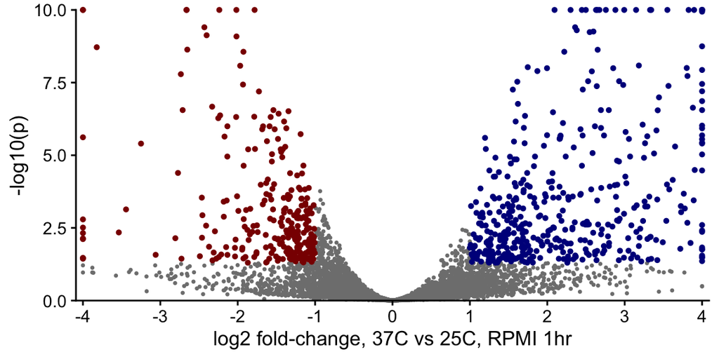

```r
volcano_37Cvs25C_YPD1hr <-
  ggplot(data = deseq_df_37Cvs25C_YPD1hr,
         aes(x = log2FC, y = -log10(padj)) ) +
  geom_point(size = 0.5, colour = "grey50") +
  geom_point(data = DEGdf_37C_up2x_FDR5,
             size = 1, colour = "darkblue") +
  geom_point(data = DEGdf_37C_down2x_FDR5,
             size = 1, colour = "darkred") +
  scale_y_continuous("-log10(p)",
                     limits = c(0,10), expand = c(0,0),
                     oob=scales::squish) +
  scale_x_continuous("log2 fold-change, 37C vs 25C, RPMI 1hr",
                     breaks = -5:5,
                     limits = c(-4,4), expand = c(0.01,0.01),
                     oob = scales::squish) +
  coord_cartesian(clip = "off")
volcano_37Cvs25C_YPD1hr
```

## Write outputs to files

```r
deseq_df_37Cvs25C_YPD1hr %>%
  dplyr::mutate(
    across(c(baseMean, log2FC, stderror), round, digits = 3)
  ) %>%
  dplyr::mutate(padj = signif(padj, digits = 4)) %>%
  write_tsv(file = here::here("results", "DEGs",
                              "deseq_df_37Cvs25C_YPD1hr.txt"))
```

```r
DEGdf_37C_up2x_FDR5 %>%
  dplyr::pull(gene) %>%
  write_lines(file = here::here("results", "DEGs",
                            "deglist_37Cvs25C_YPD1hr_up2x_FDR5.txt"))

DEGdf_37C_down2x_FDR5 %>%
  dplyr::pull(gene) %>%
  write_lines(file = here::here("results", "DEGs",
                            "deglist_37Cvs25C_YPD1hr_down2x_FDR5.txt"))
```